# ISIS 4219 - Machine Learning Techniques

## Taller 2 - Pregunta 1

Integrantes:

- Juan Camilo Cática
- Ricardo
- Diego Fernando Escobar

Los accidentes de tráfico constituyen un problema en casi cualquier país del mundo y están impactando de manera significativa en la sociedad debido al costo relacionado con muertes y lesiones. Por ejemplo, en el año 2010 la Organización Mundial de la Salud (OMS) estimó que 1.25 millones de muertes estuvieron relacionadas con lesiones producto de accidentes de este tipo. En el año 2017, las estadísticas europeas indicaron que, cada minuto, se registraron 50 muertes en la carretera. Y, en Colombia, el Ministerio de Transporte estimó un promedio de 15 fallecidos al día por este tipo de accidentes en lo que va de año, siendo la tercera causa de muerte en el país. Por esta razón, actualmente existen investigaciones que buscan determinar el efecto significativo de la gravedad de las lesiones de los conductores causadas por los accidentes de tráfico y tratar de comprender la relación entre los factores de influencia y los resultados del accidente. Una vía para obtener conocimiento que ayude a entender este fenómeno es construir un modelo con técnicas de aprendizaje que permita pronosticar la severidad de los accidentes.

**1) Carga de librerías**

```python
# Exploración de datos
import pandas as pd
import numpy as np
import pandas_profiling

# Visualización
%matplotlib inline
import matplotlib.pyplot as plt
import mglearn
import scikitplot as skplt

# Algoritmo de aprendizaje
from sklearn import metrics
from sklearn import svm
from sklearn import preprocessing
from sklearn.multiclass import OneVsRestClassifier
from sklearn.decomposition import PCA
from sklearn.preprocessing import StandardScaler
from sklearn.model_selection import train_test_split
from sklearn.model_selection import GridSearchCV

import seaborn as sns
import matplotlib.pyplot as plt
sns.set(style="ticks", color_codes=True)
```

**2) Lectura de fuentes**

```python
# Modificar esta ruta de tal modo que apunte a la dirección donde se encuentren los datos6
%cd D:\Diego\Documents\Dropbox\Andes\Machine Learning Techniques\Taller 2\Conjuntos de datos\Accidentes
#%cd C:\Users\DiegoF_Escobar\Documents\Python Scripts\Taller 1\Datos pregunta 1
dataframe_accidents = pd.read_csv("Accidents.csv", sep=",")
dataframe_accidents_dictionary = pd.read_excel("Diccionario_Accidents.xlsx", sheet_name=None)
```

```
D:\Diego\Documents\Dropbox\Andes\Machine Learning Techniques\Taller 2\Conjuntos de datos\Accidentes
```

```python
dataframe_accidents.head()
```

|  | Accident_Index | Police_Force | Accident_Severity | Number_of_Vehicles | Number_of_Casualties | Day_of_Week | Local_Authority_(District) | Road_Type | Speed_limit | Junction_Detail | Light_Conditions | Weather_Conditions | Road_Surface_Conditions | Special_Conditions_at_Site | Carriageway_Hazards | Urban_or_Rural_Area | Did_Police_Officer_Attend_Scene_of_Accident |
| --- | --- | --- | --- | --- | --- | --- | --- | --- | --- | --- | --- | --- | --- | --- | --- | --- | --- |
| 0 | 201143N077061 | 43 | 1 | 5 | 1 | 7 | 477 | 3 | 70 | 0 | 1 | 1 | 1 | 0 | 0 | 2 | 1 |
| 1 | 2009130735809 | 13 | 1 | 2 | 1 | 5 | 202 | 6 | 50 | 0 | 1 | 1 | 1 | 0 | 0 | 2 | 1 |
| 2 | 200697LB70507 | 97 | 1 | 1 | 1 | 2 | 913 | 6 | 60 | 0 | 1 | 1 | 1 | 0 | 0 | 2 | 1 |
| 3 | 200897UA70101 | 97 | 1 | 1 | 1 | 4 | 931 | 6 | 30 | 0 | 4 | 1 | 2 | 0 | 0 | 1 | 1 |
| 4 | 2005215337583 | 21 | 1 | 1 | 1 | 7 | 255 | 6 | 60 | 3 | 6 | 8 | 4 | 0 | 0 | 2 | 1 |

```python
dataframe_accidents_dictionary
```

[output not shown]

[output cut: 183 more lines]

**3) Exploración inicial de los datos**

```python
dataframe_accidents.shape
```

```
(4500, 17)
```

```python
dataframe_accidents.dtypes
```

```
Accident_Index                                 object
Police_Force                                    int64
Accident_Severity                               int64
Number_of_Vehicles                              int64
Number_of_Casualties                            int64
Day_of_Week                                     int64
Local_Authority_(District)                      int64
Road_Type                                       int64
Speed_limit                                     int64
Junction_Detail                                 int64
Light_Conditions                                int64
Weather_Conditions                              int64
Road_Surface_Conditions                         int64
Special_Conditions_at_Site                      int64
Carriageway_Hazards                             int64
Urban_or_Rural_Area                             int64
Did_Police_Officer_Attend_Scene_of_Accident     int64
dtype: object
```

Revisamos si existen datos duplicados. Según la revisión no se encuentran.

```python
dataframe_accidents.duplicated().sum()
```

```
0
```

Observamos si hay desbalance de clases.

En efecto se evidencia en el dataset que existen más accidentes de tipo 3 (Slight) que de tipo 2 (Serious) y tipo 1 (Fatal) juntos. Se tendrá en cuenta este desbalance para el análisis.

```
3    3000
2    1000
1     500
Name: Accident_Severity, dtype: int64
```

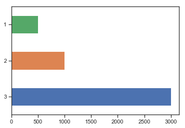

```python
print(dataframe_accidents['Accident_Severity'].value_counts())
dataframe_accidents["Accident_Severity"].value_counts().plot(kind="barh");
```

**4) Perfilamiento de datos**

Overview

Dataset info

| Number of variables | 17 |
| --- | --- |
| Number of observations | 4500 |
| Total Missing (%) | 0.0% |
| Total size in memory | 597.7 KiB |
| Average record size in memory | 136.0 B |

Variables types

| Numeric | 15 |
| --- | --- |
| Categorical | 0 |
| Boolean | 0 |
| Date | 0 |
| Text (Unique) | 1 |
| Rejected | 1 |
| Unsupported | 0 |

Warnings

- `Carriageway_Hazards` has 4413 / 98.1% zeros Zeros

- `Junction_Detail` has 1948 / 43.3% zeros Zeros

- `Local_Authority_(District)` is highly correlated with `Police_Force` (ρ = 0.98289) Rejected

- `Special_Conditions_at_Site` has 4403 / 97.8% zeros Zeros

Variables

Accident_Index  
Categorical, Unique

| First 3 values |
| --- |
| 201431C015914 |
| 20134100B0053 |
| 2008460164032 |

| Last 3 values |
| --- |
| 2014074105859 |
| 2006470610752 |
| 200943P180059 |

Toggle details

First 10 values

| Value | Count | Frequency (%) |  |
| --- | --- | --- | --- |
| 200501BS70357 | 1 | 0.0% |  |
| 200501BS70480 | 1 | 0.0% |  |
| 200501BS70779 | 1 | 0.0% |  |
| 200501CW10131 | 1 | 0.0% |  |
| 200501CW11738 | 1 | 0.0% |  |

Last 10 values

| Value | Count | Frequency (%) |  |
| --- | --- | --- | --- |
| 201497LB01203 | 1 | 0.0% |  |
| 201497LB02206 | 1 | 0.0% |  |
| 201497UD04412 | 1 | 0.0% |  |
| 201497UD05105 | 1 | 0.0% |  |
| 2014984127814 | 1 | 0.0% |  |

Accident_Severity  
Numeric

| Distinct count | 3 |
| --- | --- |
| Unique (%) | 0.1% |
| Missing (%) | 0.0% |
| Missing (n) | 0 |
| Infinite (%) | 0.0% |
| Infinite (n) | 0 |

| Mean | 2.5556 |
| --- | --- |
| Minimum | 1 |
| Maximum | 3 |
| Zeros (%) | 0.0% |

Toggle details

**Statistics**

Quantile statistics

| Minimum | 1 |
| --- | --- |
| 5-th percentile | 1 |
| Q1 | 2 |
| Median | 3 |
| Q3 | 3 |
| 95-th percentile | 3 |
| Maximum | 3 |
| Range | 2 |
| Interquartile range | 1 |

Descriptive statistics

| Standard deviation | 0.68501 |
| --- | --- |
| Coef of variation | 0.26805 |
| Kurtosis | 0.17188 |
| Mean | 2.5556 |
| MAD | 0.59259 |
| Skewness | -1.2384 |
| Sum | 11500 |
| Variance | 0.46924 |
| Memory size | 35.2 KiB |

**Histogram**

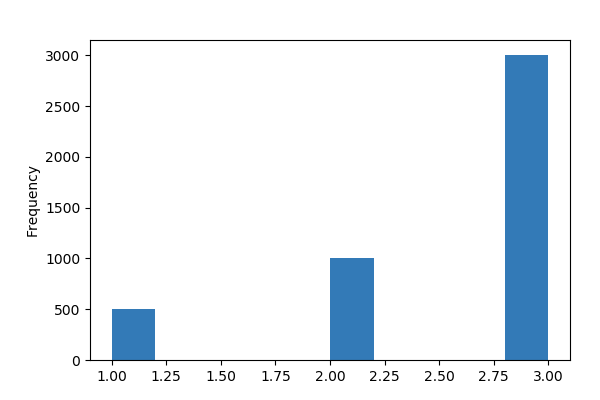

**Common Values**

| Value | Count | Frequency (%) |  |
| --- | --- | --- | --- |
| 3 | 3000 | 66.7% |  |
| 2 | 1000 | 22.2% |  |
| 1 | 500 | 11.1% |  |

**Extreme Values**

Minimum 5 values

| Value | Count | Frequency (%) |  |
| --- | --- | --- | --- |
| 1 | 500 | 11.1% |  |
| 2 | 1000 | 22.2% |  |
| 3 | 3000 | 66.7% |  |

Maximum 5 values

| Value | Count | Frequency (%) |  |
| --- | --- | --- | --- |
| 1 | 500 | 11.1% |  |
| 2 | 1000 | 22.2% |  |
| 3 | 3000 | 66.7% |  |

Carriageway_Hazards  
Numeric

| Distinct count | 7 |
| --- | --- |
| Unique (%) | 0.2% |
| Missing (%) | 0.0% |
| Missing (n) | 0 |
| Infinite (%) | 0.0% |
| Infinite (n) | 0 |

| Mean | 0.076 |
| --- | --- |
| Minimum | -1 |
| Maximum | 7 |
| Zeros (%) | 98.1% |

Toggle details

**Statistics**

Quantile statistics

| Minimum | -1 |
| --- | --- |
| 5-th percentile | 0 |
| Q1 | 0 |
| Median | 0 |
| Q3 | 0 |
| 95-th percentile | 0 |
| Maximum | 7 |
| Range | 8 |
| Interquartile range | 0 |

Descriptive statistics

| Standard deviation | 0.63147 |
| --- | --- |
| Coef of variation | 8.3088 |
| Kurtosis | 92.191 |
| Mean | 0.076 |
| MAD | 0.14954 |
| Skewness | 9.4184 |
| Sum | 342 |
| Variance | 0.39876 |
| Memory size | 35.2 KiB |

**Histogram**

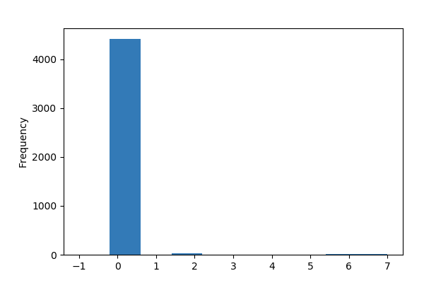

**Common Values**

| Value | Count | Frequency (%) |  |
| --- | --- | --- | --- |
| 0 | 4413 | 98.1% |  |
| 2 | 36 | 0.8% |  |
| 7 | 19 | 0.4% |  |
| 6 | 19 | 0.4% |  |
| 3 | 6 | 0.1% |  |
| 1 | 6 | 0.1% |  |
| -1 | 1 | 0.0% |  |

**Extreme Values**

Minimum 5 values

| Value | Count | Frequency (%) |  |
| --- | --- | --- | --- |
| -1 | 1 | 0.0% |  |
| 0 | 4413 | 98.1% |  |
| 1 | 6 | 0.1% |  |
| 2 | 36 | 0.8% |  |
| 3 | 6 | 0.1% |  |

Maximum 5 values

| Value | Count | Frequency (%) |  |
| --- | --- | --- | --- |
| 1 | 6 | 0.1% |  |
| 2 | 36 | 0.8% |  |
| 3 | 6 | 0.1% |  |
| 6 | 19 | 0.4% |  |
| 7 | 19 | 0.4% |  |

Day_of_Week  
Numeric

| Distinct count | 7 |
| --- | --- |
| Unique (%) | 0.2% |
| Missing (%) | 0.0% |
| Missing (n) | 0 |
| Infinite (%) | 0.0% |
| Infinite (n) | 0 |

| Mean | 4.1409 |
| --- | --- |
| Minimum | 1 |
| Maximum | 7 |
| Zeros (%) | 0.0% |

Toggle details

**Statistics**

Quantile statistics

| Minimum | 1 |
| --- | --- |
| 5-th percentile | 1 |
| Q1 | 2 |
| Median | 4 |
| Q3 | 6 |
| 95-th percentile | 7 |
| Maximum | 7 |
| Range | 6 |
| Interquartile range | 4 |

Descriptive statistics

| Standard deviation | 1.944 |
| --- | --- |
| Coef of variation | 0.46947 |
| Kurtosis | -1.2048 |
| Mean | 4.1409 |
| MAD | 1.6793 |
| Skewness | -0.096282 |
| Sum | 18634 |
| Variance | 3.7792 |
| Memory size | 35.2 KiB |

**Histogram**

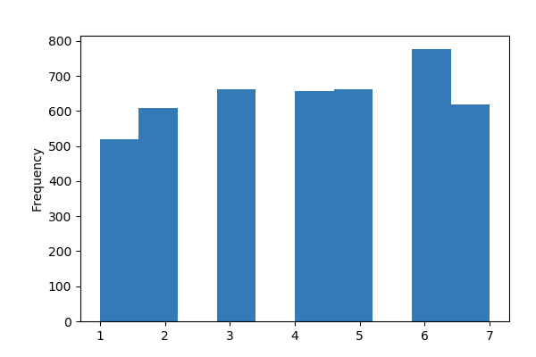

**Common Values**

| Value | Count | Frequency (%) |  |
| --- | --- | --- | --- |
| 6 | 776 | 17.2% |  |
| 5 | 662 | 14.7% |  |
| 3 | 661 | 14.7% |  |
| 4 | 656 | 14.6% |  |
| 7 | 618 | 13.7% |  |
| 2 | 608 | 13.5% |  |
| 1 | 519 | 11.5% |  |

**Extreme Values**

Minimum 5 values

| Value | Count | Frequency (%) |  |
| --- | --- | --- | --- |
| 1 | 519 | 11.5% |  |
| 2 | 608 | 13.5% |  |
| 3 | 661 | 14.7% |  |
| 4 | 656 | 14.6% |  |
| 5 | 662 | 14.7% |  |

Maximum 5 values

| Value | Count | Frequency (%) |  |
| --- | --- | --- | --- |
| 3 | 661 | 14.7% |  |
| 4 | 656 | 14.6% |  |
| 5 | 662 | 14.7% |  |
| 6 | 776 | 17.2% |  |
| 7 | 618 | 13.7% |  |

Did_Police_Officer_Attend_Scene_of_Accident  
Numeric

| Distinct count | 3 |
| --- | --- |
| Unique (%) | 0.1% |
| Missing (%) | 0.0% |
| Missing (n) | 0 |
| Infinite (%) | 0.0% |
| Infinite (n) | 0 |

| Mean | 1.1638 |
| --- | --- |
| Minimum | 1 |
| Maximum | 3 |
| Zeros (%) | 0.0% |

Toggle details

**Statistics**

Quantile statistics

| Minimum | 1 |
| --- | --- |
| 5-th percentile | 1 |
| Q1 | 1 |
| Median | 1 |
| Q3 | 1 |
| 95-th percentile | 2 |
| Maximum | 3 |
| Range | 2 |
| Interquartile range | 0 |

Descriptive statistics

| Standard deviation | 0.3743 |
| --- | --- |
| Coef of variation | 0.32162 |
| Kurtosis | 1.9401 |
| Mean | 1.1638 |
| MAD | 0.27442 |
| Skewness | 1.9064 |
| Sum | 5237 |
| Variance | 0.1401 |
| Memory size | 35.2 KiB |

**Histogram**

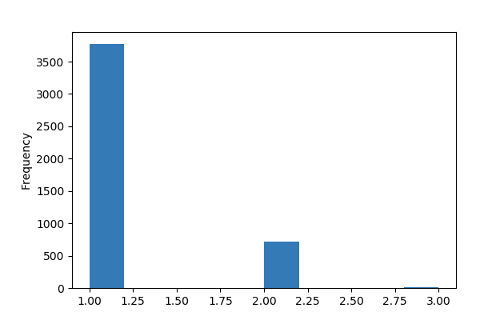

**Common Values**

| Value | Count | Frequency (%) |  |
| --- | --- | --- | --- |
| 1 | 3770 | 83.8% |  |
| 2 | 723 | 16.1% |  |
| 3 | 7 | 0.2% |  |

**Extreme Values**

Minimum 5 values

| Value | Count | Frequency (%) |  |
| --- | --- | --- | --- |
| 1 | 3770 | 83.8% |  |
| 2 | 723 | 16.1% |  |
| 3 | 7 | 0.2% |  |

Maximum 5 values

| Value | Count | Frequency (%) |  |
| --- | --- | --- | --- |
| 1 | 3770 | 83.8% |  |
| 2 | 723 | 16.1% |  |
| 3 | 7 | 0.2% |  |

Junction_Detail  
Numeric

| Distinct count | 9 |
| --- | --- |
| Unique (%) | 0.2% |
| Missing (%) | 0.0% |
| Missing (n) | 0 |
| Infinite (%) | 0.0% |
| Infinite (n) | 0 |

| Mean | 2.2647 |
| --- | --- |
| Minimum | 0 |
| Maximum | 9 |
| Zeros (%) | 43.3% |

Toggle details

**Statistics**

Quantile statistics

| Minimum | 0 |
| --- | --- |
| 5-th percentile | 0 |
| Q1 | 0 |
| Median | 1 |
| Q3 | 3 |
| 95-th percentile | 8 |
| Maximum | 9 |
| Range | 9 |
| Interquartile range | 3 |

Descriptive statistics

| Standard deviation | 2.6074 |
| --- | --- |
| Coef of variation | 1.1513 |
| Kurtosis | 0.036577 |
| Mean | 2.2647 |
| MAD | 2.1609 |
| Skewness | 1.0031 |
| Sum | 10191 |
| Variance | 6.7984 |
| Memory size | 35.2 KiB |

**Histogram**

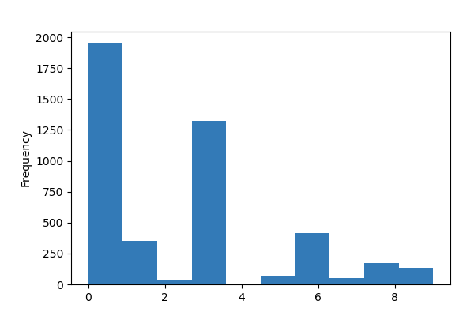

**Common Values**

| Value | Count | Frequency (%) |  |
| --- | --- | --- | --- |
| 0 | 1948 | 43.3% |  |
| 3 | 1326 | 29.5% |  |
| 6 | 413 | 9.2% |  |
| 1 | 349 | 7.8% |  |
| 8 | 172 | 3.8% |  |
| 9 | 137 | 3.0% |  |
| 5 | 69 | 1.5% |  |
| 7 | 52 | 1.2% |  |
| 2 | 34 | 0.8% |  |

**Extreme Values**

Minimum 5 values

| Value | Count | Frequency (%) |  |
| --- | --- | --- | --- |
| 0 | 1948 | 43.3% |  |
| 1 | 349 | 7.8% |  |
| 2 | 34 | 0.8% |  |
| 3 | 1326 | 29.5% |  |
| 5 | 69 | 1.5% |  |

Maximum 5 values

| Value | Count | Frequency (%) |  |
| --- | --- | --- | --- |
| 5 | 69 | 1.5% |  |
| 6 | 413 | 9.2% |  |
| 7 | 52 | 1.2% |  |
| 8 | 172 | 3.8% |  |
| 9 | 137 | 3.0% |  |

Light_Conditions  
Numeric

| Distinct count | 5 |
| --- | --- |
| Unique (%) | 0.1% |
| Missing (%) | 0.0% |
| Missing (n) | 0 |
| Infinite (%) | 0.0% |
| Infinite (n) | 0 |

| Mean | 2.0602 |
| --- | --- |
| Minimum | 1 |
| Maximum | 7 |
| Zeros (%) | 0.0% |

Toggle details

**Statistics**

Quantile statistics

| Minimum | 1 |
| --- | --- |
| 5-th percentile | 1 |
| Q1 | 1 |
| Median | 1 |
| Q3 | 4 |
| 95-th percentile | 6 |
| Maximum | 7 |
| Range | 6 |
| Interquartile range | 3 |

Descriptive statistics

| Standard deviation | 1.7234 |
| --- | --- |
| Coef of variation | 0.83652 |
| Kurtosis | 0.1244 |
| Mean | 2.0602 |
| MAD | 1.4961 |
| Skewness | 1.249 |
| Sum | 9271 |
| Variance | 2.9701 |
| Memory size | 35.2 KiB |

**Histogram**

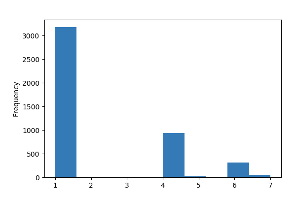

**Common Values**

| Value | Count | Frequency (%) |  |
| --- | --- | --- | --- |
| 1 | 3175 | 70.6% |  |
| 4 | 941 | 20.9% |  |
| 6 | 312 | 6.9% |  |
| 7 | 50 | 1.1% |  |
| 5 | 22 | 0.5% |  |

**Extreme Values**

Minimum 5 values

| Value | Count | Frequency (%) |  |
| --- | --- | --- | --- |
| 1 | 3175 | 70.6% |  |
| 4 | 941 | 20.9% |  |
| 5 | 22 | 0.5% |  |
| 6 | 312 | 6.9% |  |
| 7 | 50 | 1.1% |  |

Maximum 5 values

| Value | Count | Frequency (%) |  |
| --- | --- | --- | --- |
| 1 | 3175 | 70.6% |  |
| 4 | 941 | 20.9% |  |
| 5 | 22 | 0.5% |  |
| 6 | 312 | 6.9% |  |
| 7 | 50 | 1.1% |  |

Local_Authority_(District)  
Highly correlated

*This variable is highly correlated with `Police_Force` and should be ignored for analysis*

| Correlation | 0.98289 |
| --- | --- |

Number_of_Casualties  
Numeric

| Distinct count | 12 |
| --- | --- |
| Unique (%) | 0.3% |
| Missing (%) | 0.0% |
| Missing (n) | 0 |
| Infinite (%) | 0.0% |
| Infinite (n) | 0 |

| Mean | 1.3847 |
| --- | --- |
| Minimum | 1 |
| Maximum | 17 |
| Zeros (%) | 0.0% |

Toggle details

**Statistics**

Quantile statistics

| Minimum | 1 |
| --- | --- |
| 5-th percentile | 1 |
| Q1 | 1 |
| Median | 1 |
| Q3 | 1 |
| 95-th percentile | 3 |
| Maximum | 17 |
| Range | 16 |
| Interquartile range | 0 |

Descriptive statistics

| Standard deviation | 0.87482 |
| --- | --- |
| Coef of variation | 0.63179 |
| Kurtosis | 41.669 |
| Mean | 1.3847 |
| MAD | 0.57956 |
| Skewness | 4.5309 |
| Sum | 6231 |
| Variance | 0.76531 |
| Memory size | 35.2 KiB |

**Histogram**

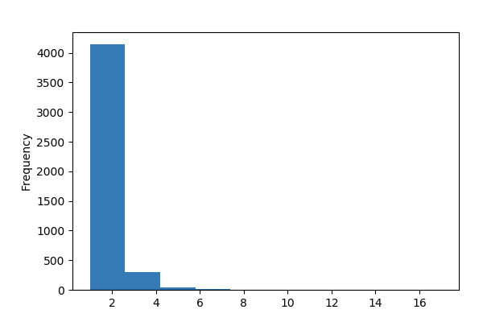

**Common Values**

| Value | Count | Frequency (%) |  |
| --- | --- | --- | --- |
| 1 | 3390 | 75.3% |  |
| 2 | 752 | 16.7% |  |
| 3 | 210 | 4.7% |  |
| 4 | 91 | 2.0% |  |
| 5 | 37 | 0.8% |  |
| 6 | 8 | 0.2% |  |
| 7 | 5 | 0.1% |  |
| 9 | 2 | 0.0% |  |
| 8 | 2 | 0.0% |  |
| 11 | 1 | 0.0% |  |
| Other values (2) | 2 | 0.0% |  |

**Extreme Values**

Minimum 5 values

| Value | Count | Frequency (%) |  |
| --- | --- | --- | --- |
| 1 | 3390 | 75.3% |  |
| 2 | 752 | 16.7% |  |
| 3 | 210 | 4.7% |  |
| 4 | 91 | 2.0% |  |
| 5 | 37 | 0.8% |  |

Maximum 5 values

| Value | Count | Frequency (%) |  |
| --- | --- | --- | --- |
| 8 | 2 | 0.0% |  |
| 9 | 2 | 0.0% |  |
| 11 | 1 | 0.0% |  |
| 13 | 1 | 0.0% |  |
| 17 | 1 | 0.0% |  |

Number_of_Vehicles  
Numeric

| Distinct count | 8 |
| --- | --- |
| Unique (%) | 0.2% |
| Missing (%) | 0.0% |
| Missing (n) | 0 |
| Infinite (%) | 0.0% |
| Infinite (n) | 0 |

| Mean | 1.7956 |
| --- | --- |
| Minimum | 1 |
| Maximum | 8 |
| Zeros (%) | 0.0% |

Toggle details

**Statistics**

Quantile statistics

| Minimum | 1 |
| --- | --- |
| 5-th percentile | 1 |
| Q1 | 1 |
| Median | 2 |
| Q3 | 2 |
| 95-th percentile | 3 |
| Maximum | 8 |
| Range | 7 |
| Interquartile range | 1 |

Descriptive statistics

| Standard deviation | 0.71436 |
| --- | --- |
| Coef of variation | 0.39785 |
| Kurtosis | 4.6606 |
| Mean | 1.7956 |
| MAD | 0.53461 |
| Skewness | 1.2691 |
| Sum | 8080 |
| Variance | 0.51032 |
| Memory size | 35.2 KiB |

**Histogram**

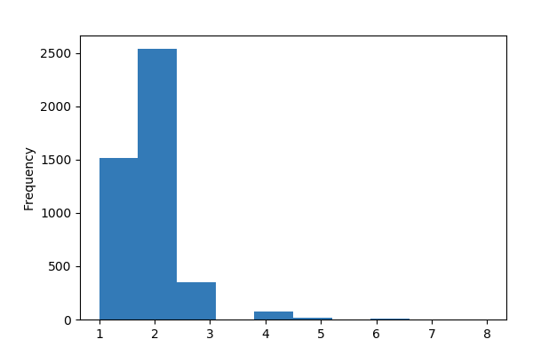

**Common Values**

| Value | Count | Frequency (%) |  |
| --- | --- | --- | --- |
| 2 | 2536 | 56.4% |  |
| 1 | 1512 | 33.6% |  |
| 3 | 348 | 7.7% |  |
| 4 | 78 | 1.7% |  |
| 5 | 19 | 0.4% |  |
| 6 | 5 | 0.1% |  |
| 7 | 1 | 0.0% |  |
| 8 | 1 | 0.0% |  |

**Extreme Values**

Minimum 5 values

| Value | Count | Frequency (%) |  |
| --- | --- | --- | --- |
| 1 | 1512 | 33.6% |  |
| 2 | 2536 | 56.4% |  |
| 3 | 348 | 7.7% |  |
| 4 | 78 | 1.7% |  |
| 5 | 19 | 0.4% |  |

Maximum 5 values

| Value | Count | Frequency (%) |  |
| --- | --- | --- | --- |
| 4 | 78 | 1.7% |  |
| 5 | 19 | 0.4% |  |
| 6 | 5 | 0.1% |  |
| 7 | 1 | 0.0% |  |
| 8 | 1 | 0.0% |  |

Police_Force  
Numeric

| Distinct count | 51 |
| --- | --- |
| Unique (%) | 1.1% |
| Missing (%) | 0.0% |
| Missing (n) | 0 |
| Infinite (%) | 0.0% |
| Infinite (n) | 0 |

| Mean | 31.595 |
| --- | --- |
| Minimum | 1 |
| Maximum | 98 |
| Zeros (%) | 0.0% |

Toggle details

**Statistics**

Quantile statistics

| Minimum | 1 |
| --- | --- |
| 5-th percentile | 1 |
| Q1 | 10 |
| Median | 31 |
| Q3 | 46 |
| 95-th percentile | 95 |
| Maximum | 98 |
| Range | 97 |
| Interquartile range | 36 |

Descriptive statistics

| Standard deviation | 25.653 |
| --- | --- |
| Coef of variation | 0.81194 |
| Kurtosis | 0.26825 |
| Mean | 31.595 |
| MAD | 20.973 |
| Skewness | 0.81248 |
| Sum | 142178 |
| Variance | 658.1 |
| Memory size | 35.2 KiB |

**Histogram**

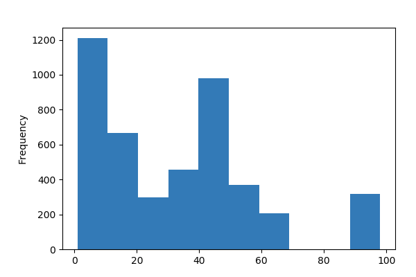

**Common Values**

| Value | Count | Frequency (%) |  |
| --- | --- | --- | --- |
| 1 | 620 | 13.8% |  |
| 20 | 187 | 4.2% |  |
| 43 | 170 | 3.8% |  |
| 46 | 167 | 3.7% |  |
| 13 | 162 | 3.6% |  |
| 6 | 155 | 3.4% |  |
| 44 | 135 | 3.0% |  |
| 97 | 133 | 3.0% |  |
| 47 | 130 | 2.9% |  |
| 42 | 129 | 2.9% |  |
| Other values (41) | 2512 | 55.8% |  |

**Extreme Values**

Minimum 5 values

| Value | Count | Frequency (%) |  |
| --- | --- | --- | --- |
| 1 | 620 | 13.8% |  |
| 3 | 35 | 0.8% |  |
| 4 | 120 | 2.7% |  |
| 5 | 107 | 2.4% |  |
| 6 | 155 | 3.4% |  |

Maximum 5 values

| Value | Count | Frequency (%) |  |
| --- | --- | --- | --- |
| 94 | 14 | 0.3% |  |
| 95 | 74 | 1.6% |  |
| 96 | 13 | 0.3% |  |
| 97 | 133 | 3.0% |  |
| 98 | 10 | 0.2% |  |

Road_Surface_Conditions  
Numeric

| Distinct count | 6 |
| --- | --- |
| Unique (%) | 0.1% |
| Missing (%) | 0.0% |
| Missing (n) | 0 |
| Infinite (%) | 0.0% |
| Infinite (n) | 0 |

| Mean | 1.3562 |
| --- | --- |
| Minimum | -1 |
| Maximum | 5 |
| Zeros (%) | 0.0% |

Toggle details

**Statistics**

Quantile statistics

| Minimum | -1 |
| --- | --- |
| 5-th percentile | 1 |
| Q1 | 1 |
| Median | 1 |
| Q3 | 2 |
| 95-th percentile | 2 |
| Maximum | 5 |
| Range | 6 |
| Interquartile range | 1 |

Descriptive statistics

| Standard deviation | 0.60559 |
| --- | --- |
| Coef of variation | 0.44653 |
| Kurtosis | 5.8368 |
| Mean | 1.3562 |
| MAD | 0.49302 |
| Skewness | 1.9667 |
| Sum | 6103 |
| Variance | 0.36674 |
| Memory size | 35.2 KiB |

**Histogram**

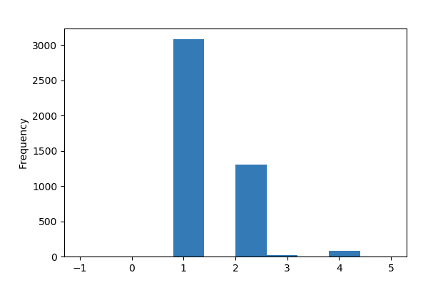

**Common Values**

| Value | Count | Frequency (%) |  |
| --- | --- | --- | --- |
| 1 | 3081 | 68.5% |  |
| 2 | 1306 | 29.0% |  |
| 4 | 83 | 1.8% |  |
| 3 | 21 | 0.5% |  |
| -1 | 5 | 0.1% |  |
| 5 | 4 | 0.1% |  |

**Extreme Values**

Minimum 5 values

| Value | Count | Frequency (%) |  |
| --- | --- | --- | --- |
| -1 | 5 | 0.1% |  |
| 1 | 3081 | 68.5% |  |
| 2 | 1306 | 29.0% |  |
| 3 | 21 | 0.5% |  |
| 4 | 83 | 1.8% |  |

Maximum 5 values

| Value | Count | Frequency (%) |  |
| --- | --- | --- | --- |
| 1 | 3081 | 68.5% |  |
| 2 | 1306 | 29.0% |  |
| 3 | 21 | 0.5% |  |
| 4 | 83 | 1.8% |  |
| 5 | 4 | 0.1% |  |

Road_Type  
Numeric

| Distinct count | 6 |
| --- | --- |
| Unique (%) | 0.1% |
| Missing (%) | 0.0% |
| Missing (n) | 0 |
| Infinite (%) | 0.0% |
| Infinite (n) | 0 |

| Mean | 5.1702 |
| --- | --- |
| Minimum | 1 |
| Maximum | 9 |
| Zeros (%) | 0.0% |

Toggle details

**Statistics**

Quantile statistics

| Minimum | 1 |
| --- | --- |
| 5-th percentile | 1 |
| Q1 | 6 |
| Median | 6 |
| Q3 | 6 |
| 95-th percentile | 6 |
| Maximum | 9 |
| Range | 8 |
| Interquartile range | 0 |

Descriptive statistics

| Standard deviation | 1.6098 |
| --- | --- |
| Coef of variation | 0.31137 |
| Kurtosis | 0.68574 |
| Mean | 5.1702 |
| MAD | 1.3121 |
| Skewness | -1.3625 |
| Sum | 23266 |
| Variance | 2.5916 |
| Memory size | 35.2 KiB |

**Histogram**

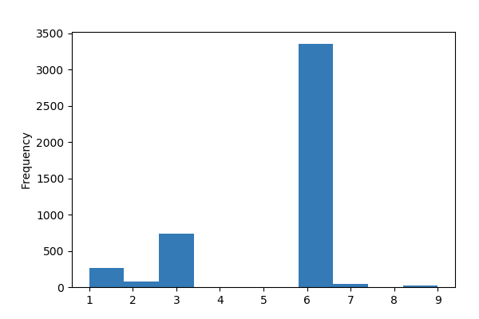

**Common Values**

| Value | Count | Frequency (%) |  |
| --- | --- | --- | --- |
| 6 | 3352 | 74.5% |  |
| 3 | 741 | 16.5% |  |
| 1 | 263 | 5.8% |  |
| 2 | 78 | 1.7% |  |
| 7 | 41 | 0.9% |  |
| 9 | 25 | 0.6% |  |

**Extreme Values**

Minimum 5 values

| Value | Count | Frequency (%) |  |
| --- | --- | --- | --- |
| 1 | 263 | 5.8% |  |
| 2 | 78 | 1.7% |  |
| 3 | 741 | 16.5% |  |
| 6 | 3352 | 74.5% |  |
| 7 | 41 | 0.9% |  |

Maximum 5 values

| Value | Count | Frequency (%) |  |
| --- | --- | --- | --- |
| 2 | 78 | 1.7% |  |
| 3 | 741 | 16.5% |  |
| 6 | 3352 | 74.5% |  |
| 7 | 41 | 0.9% |  |
| 9 | 25 | 0.6% |  |

Special_Conditions_at_Site  
Numeric

| Distinct count | 8 |
| --- | --- |
| Unique (%) | 0.2% |
| Missing (%) | 0.0% |
| Missing (n) | 0 |
| Infinite (%) | 0.0% |
| Infinite (n) | 0 |

| Mean | 0.096889 |
| --- | --- |
| Minimum | 0 |
| Maximum | 7 |
| Zeros (%) | 97.8% |

Toggle details

**Statistics**

Quantile statistics

| Minimum | 0 |
| --- | --- |
| 5-th percentile | 0 |
| Q1 | 0 |
| Median | 0 |
| Q3 | 0 |
| 95-th percentile | 0 |
| Maximum | 7 |
| Range | 7 |
| Interquartile range | 0 |

Descriptive statistics

| Standard deviation | 0.69606 |
| --- | --- |
| Coef of variation | 7.1841 |
| Kurtosis | 59.941 |
| Mean | 0.096889 |
| MAD | 0.1896 |
| Skewness | 7.6333 |
| Sum | 436 |
| Variance | 0.4845 |
| Memory size | 35.2 KiB |

**Histogram**

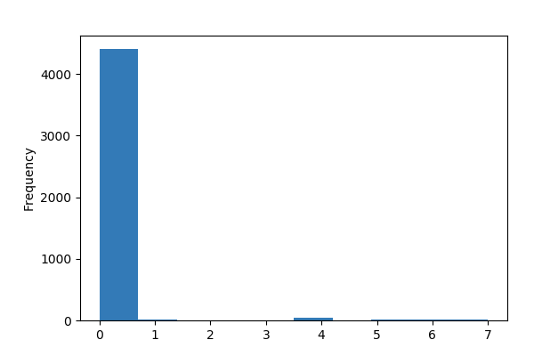

**Common Values**

| Value | Count | Frequency (%) |  |
| --- | --- | --- | --- |
| 0 | 4403 | 97.8% |  |
| 4 | 44 | 1.0% |  |
| 6 | 16 | 0.4% |  |
| 7 | 14 | 0.3% |  |
| 5 | 8 | 0.2% |  |
| 1 | 8 | 0.2% |  |
| 3 | 4 | 0.1% |  |
| 2 | 3 | 0.1% |  |

**Extreme Values**

Minimum 5 values

| Value | Count | Frequency (%) |  |
| --- | --- | --- | --- |
| 0 | 4403 | 97.8% |  |
| 1 | 8 | 0.2% |  |
| 2 | 3 | 0.1% |  |
| 3 | 4 | 0.1% |  |
| 4 | 44 | 1.0% |  |

Maximum 5 values

| Value | Count | Frequency (%) |  |
| --- | --- | --- | --- |
| 3 | 4 | 0.1% |  |
| 4 | 44 | 1.0% |  |
| 5 | 8 | 0.2% |  |
| 6 | 16 | 0.4% |  |
| 7 | 14 | 0.3% |  |

Speed_limit  
Numeric

| Distinct count | 6 |
| --- | --- |
| Unique (%) | 0.1% |
| Missing (%) | 0.0% |
| Missing (n) | 0 |
| Infinite (%) | 0.0% |
| Infinite (n) | 0 |

| Mean | 40.151 |
| --- | --- |
| Minimum | 20 |
| Maximum | 70 |
| Zeros (%) | 0.0% |

Toggle details

**Statistics**

Quantile statistics

| Minimum | 20 |
| --- | --- |
| 5-th percentile | 30 |
| Q1 | 30 |
| Median | 30 |
| Q3 | 60 |
| 95-th percentile | 70 |
| Maximum | 70 |
| Range | 50 |
| Interquartile range | 30 |

Descriptive statistics

| Standard deviation | 14.652 |
| --- | --- |
| Coef of variation | 0.36493 |
| Kurtosis | -0.76733 |
| Mean | 40.151 |
| MAD | 12.732 |
| Skewness | 0.93113 |
| Sum | 180680 |
| Variance | 214.69 |
| Memory size | 35.2 KiB |

**Histogram**

[5 more figures not shown]

Sample

|  | Accident_Index | Police_Force | Accident_Severity | Number_of_Vehicles | Number_of_Casualties | Day_of_Week | Local_Authority_(District) | Road_Type | Speed_limit | Junction_Detail | Light_Conditions | Weather_Conditions | Road_Surface_Conditions | Special_Conditions_at_Site | Carriageway_Hazards | Urban_or_Rural_Area | Did_Police_Officer_Attend_Scene_of_Accident |
| --- | --- | --- | --- | --- | --- | --- | --- | --- | --- | --- | --- | --- | --- | --- | --- | --- | --- |
| 0 | 201143N077061 | 43 | 1 | 5 | 1 | 7 | 477 | 3 | 70 | 0 | 1 | 1 | 1 | 0 | 0 | 2 | 1 |
| 1 | 2009130735809 | 13 | 1 | 2 | 1 | 5 | 202 | 6 | 50 | 0 | 1 | 1 | 1 | 0 | 0 | 2 | 1 |
| 2 | 200697LB70507 | 97 | 1 | 1 | 1 | 2 | 913 | 6 | 60 | 0 | 1 | 1 | 1 | 0 | 0 | 2 | 1 |
| 3 | 200897UA70101 | 97 | 1 | 1 | 1 | 4 | 931 | 6 | 30 | 0 | 4 | 1 | 2 | 0 | 0 | 1 | 1 |
| 4 | 2005215337583 | 21 | 1 | 1 | 1 | 7 | 255 | 6 | 60 | 3 | 6 | 8 | 4 | 0 | 0 | 2 | 1 |

```python
report = pandas_profiling.ProfileReport(dataframe_accidents)
report
```

```python
rejected_var_list = report.get_rejected_variables()
rejected_var_list
```

```
['Local_Authority_(District)']
```

Producto del análisis de las variables, se observa que las siguientes variables pueden no aportar al modelo:

- Accident_Index: Se trata de un índice que no aporta a la investigación
- Police_Force: Está altamente correlacionada con la variable Local_Authority_(District) y aunque la zona puede ser relevente para el estudio, en este análisis se supone que no tiene incidencia.
- Local_Authority_(District): Está altamente correlacionada con la variable Police Force y aunque la zona puede ser relevente para el estudio, en este análisis se supone que no tiene incidencia.

Estas variables se eliminarán inmediatamente finalice la exploración de los datos

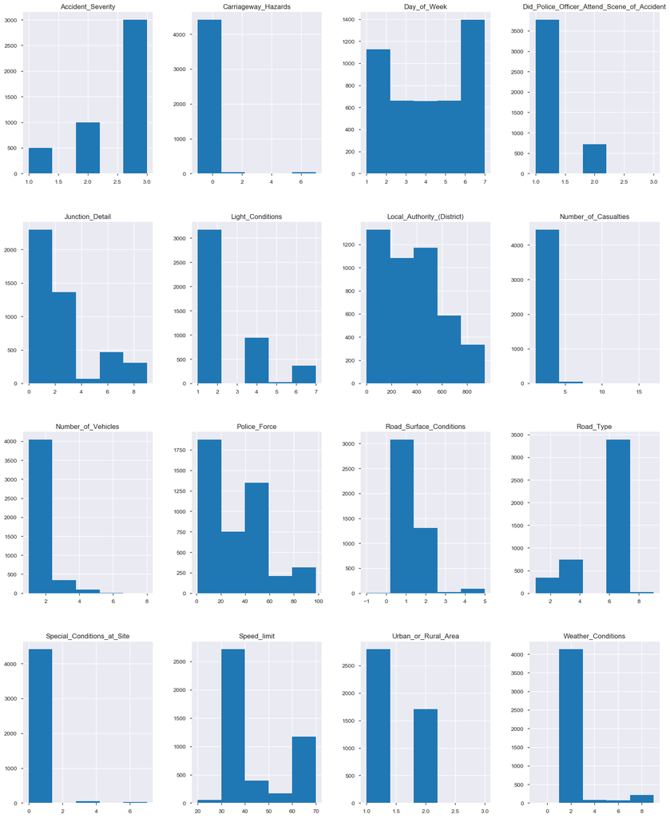

```python
dataframe_accidents.hist(bins=5, figsize=(20,25));
```

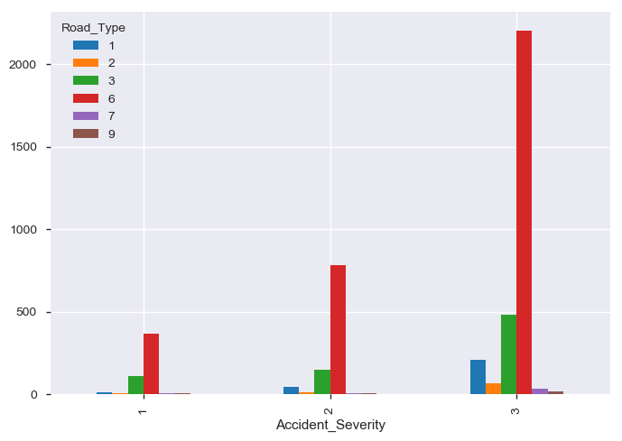

```python
dataframe_accidents.groupby('Road_Type').Accident_Severity.value_counts().unstack(0).plot.bar()
```

Se observa en el gráfico anterior que el tipo de calzada 6 (Single carriageway) es el que más accidentes prevalece

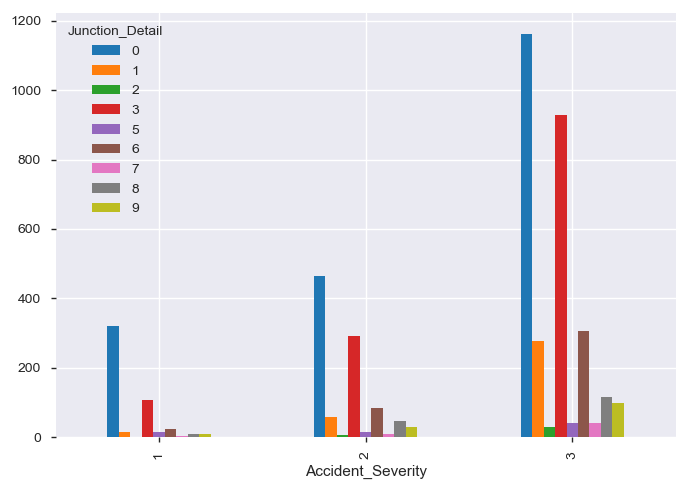

```python
dataframe_accidents.groupby('Junction_Detail').Accident_Severity.value_counts().unstack(0).plot.bar()
```

Se observa en el gráfico anterior que el detalle del tipo de calle por el que más ocurren choques son 0 (Not at junction or within 20 metres) y 3 (T or staggered junction)

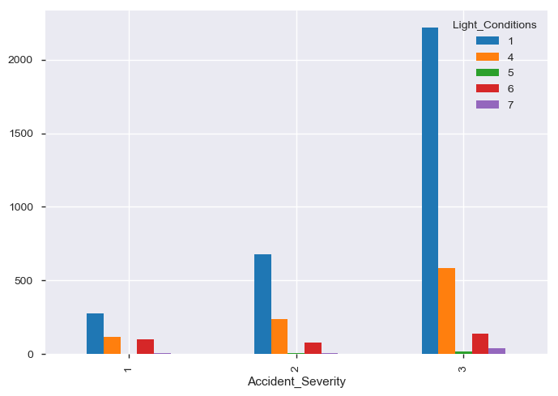

```python
dataframe_accidents.groupby('Light_Conditions').Accident_Severity.value_counts().unstack(0).plot.bar()
```

Se observa en el gráfico anterior, que la condición de iluminación más prevalente en los choques es 1 (Luz del día)

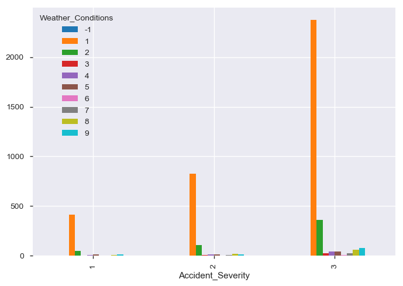

```python
dataframe_accidents.groupby('Weather_Conditions').Accident_Severity.value_counts().unstack(0).plot.bar()
```

Se observa en el gráfico anterior que la condición climática más prevalente en el conjunto de datos es 1 (Fine no high winds)

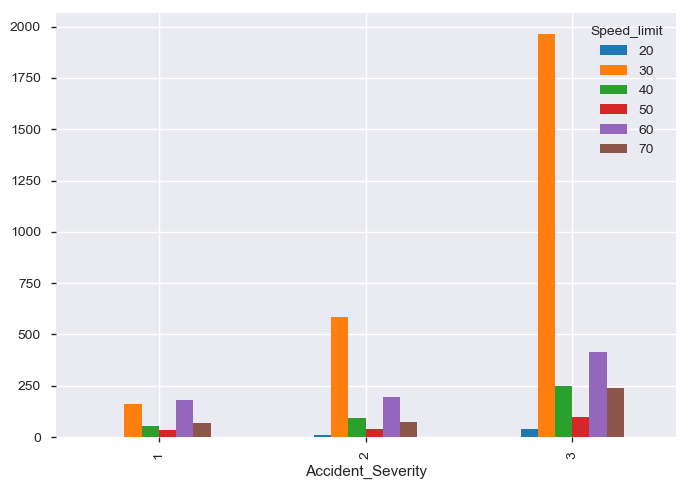

```python
dataframe_accidents.groupby('Speed_limit').Accident_Severity.value_counts().unstack(0).plot.bar()
```

Se observa que gran parte de los choques leves (3) y serios (2) tuvieron lugar en una vía con límite de velocidad de 30 (Km/h). Entre tanto en los choques fatales ocurrieron casi que repartido en partes iguales en vías con limite de velocidad 30 y 60

**5) Preparación de los datos para entrenar el modelo**

Realizamos una copia del dataframe original

```python
dataframe_accidents_prepared = dataframe_accidents.copy()
```

Eliminamos las columnas identificadas anteriormente

```python
dataframe_accidents_prepared = dataframe_accidents_prepared.drop("Accident_Index", axis = 1)
dataframe_accidents_prepared = dataframe_accidents_prepared.drop("Police_Force", axis = 1)
dataframe_accidents_prepared = dataframe_accidents_prepared.drop("Local_Authority_(District)", axis = 1)
```

```python
dataframe_accidents_prepared.columns
```

```
Index(['Accident_Severity', 'Number_of_Vehicles', 'Number_of_Casualties',
       'Day_of_Week', 'Road_Type', 'Speed_limit', 'Junction_Detail',
       'Light_Conditions', 'Weather_Conditions', 'Road_Surface_Conditions',
       'Special_Conditions_at_Site', 'Carriageway_Hazards',
       'Urban_or_Rural_Area', 'Did_Police_Officer_Attend_Scene_of_Accident'],
      dtype='object')
```

A continuación, dividimos el dataframe obteniendo los datos (X) y la clase objetivo (Y) por separado.

```python
# Dividimos la clase del dataframe
dataframe_accidents_prepared_data = dataframe_accidents_prepared[['Number_of_Vehicles', 'Number_of_Casualties',
       'Day_of_Week', 'Road_Type', 'Speed_limit', 'Junction_Detail',
       'Light_Conditions', 'Weather_Conditions', 'Road_Surface_Conditions',
       'Special_Conditions_at_Site', 'Carriageway_Hazards',
       'Urban_or_Rural_Area', 'Did_Police_Officer_Attend_Scene_of_Accident']]
dataframe_accidents_prepared_target = dataframe_accidents_prepared[['Accident_Severity']]

X = dataframe_accidents_prepared_data
y = dataframe_accidents_prepared_target
print(X.shape)
print(y.shape)
```

```
(4500, 13)
(4500, 1)
```

A continuación, escalamos las variables para obtener el mejor rendimiento

```python
min_max_scaler = preprocessing.MinMaxScaler()
```

```python
X_scaled = min_max_scaler.fit_transform(X)

X_scaled_df = pd.DataFrame(X_scaled, columns = X.columns)
X_scaled_df.columns;
```

```python
X_scaled_df.head()
```

|  | Number_of_Vehicles | Number_of_Casualties | Day_of_Week | Road_Type | Speed_limit | Junction_Detail | Light_Conditions | Weather_Conditions | Road_Surface_Conditions | Special_Conditions_at_Site | Carriageway_Hazards | Urban_or_Rural_Area | Did_Police_Officer_Attend_Scene_of_Accident |
| --- | --- | --- | --- | --- | --- | --- | --- | --- | --- | --- | --- | --- | --- |
| 0 | 0.571429 | 0.0 | 1.000000 | 0.250 | 1.0 | 0.000000 | 0.000000 | 0.2 | 0.333333 | 0.0 | 0.125 | 0.5 | 0.0 |
| 1 | 0.142857 | 0.0 | 0.666667 | 0.625 | 0.6 | 0.000000 | 0.000000 | 0.2 | 0.333333 | 0.0 | 0.125 | 0.5 | 0.0 |
| 2 | 0.000000 | 0.0 | 0.166667 | 0.625 | 0.8 | 0.000000 | 0.000000 | 0.2 | 0.333333 | 0.0 | 0.125 | 0.5 | 0.0 |
| 3 | 0.000000 | 0.0 | 0.500000 | 0.625 | 0.2 | 0.000000 | 0.500000 | 0.2 | 0.500000 | 0.0 | 0.125 | 0.0 | 0.0 |
| 4 | 0.000000 | 0.0 | 1.000000 | 0.625 | 0.8 | 0.333333 | 0.833333 | 0.9 | 0.833333 | 0.0 | 0.125 | 0.5 | 0.0 |

Finalmente, dividimos el conjunto de test y de pruebas

```python
X_train, X_test, y_train, y_test = train_test_split(X_scaled_df, y, test_size=0.3)
print (X.shape, y.shape)
print (X_train.shape, y_train.shape)
print (X_test.shape, y_test.shape)
```

```
(4500, 13) (4500, 1)
(3150, 13) (3150, 1)
(1350, 13) (1350, 1)
```

**6) Entrenamiento del modelo - SVM sin costo**

De acuerdo a las indicaciones del taller, se realiza SVM sin costo:

Dado que se trata de un ejercicio multiclase, parametrizamos

```python
svm_model_1 = svm.SVC(gamma='scale', decision_function_shape='ovo')
#svm_model_1 = svm.LinearSVC(class_weight='balanced')
svm_model_1.fit(X_train, y_train.values.ravel())
print('Accuracy of SVM classifier on training set: {:.2f}'.format(svm_model_1.score(X_train, y_train)))
print('Accuracy of SVM classifier on test set: {:.2f}'.format(svm_model_1.score(X_test, y_test)))
```

```
Accuracy of SVM classifier on training set: 0.66
Accuracy of SVM classifier on test set: 0.67
```

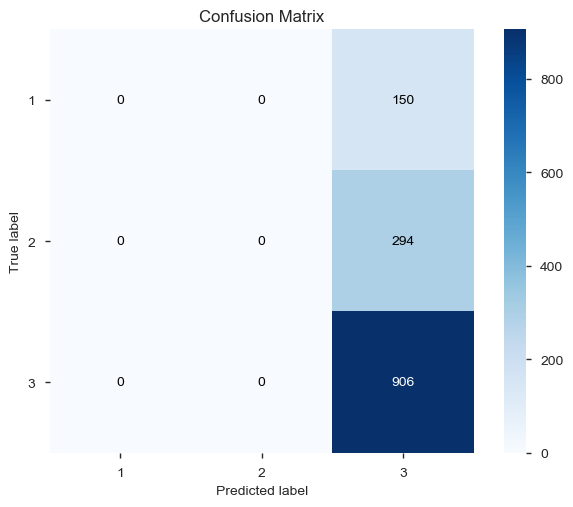

```python
y_preds_1 = svm_model_1.predict(X_test)
skplt.metrics.plot_confusion_matrix(y_test, y_preds_1)
plt.show()
```

```python
print(metrics.classification_report(y_test, y_preds_1, labels=[1,2,3], target_names=['Fatal', 'Serious', 'Slight']))
```

```
              precision    recall  f1-score   support

       Fatal       0.00      0.00      0.00       150
     Serious       0.00      0.00      0.00       294
      Slight       0.67      1.00      0.80       906

   micro avg       0.67      0.67      0.67      1350
   macro avg       0.22      0.33      0.27      1350
weighted avg       0.45      0.67      0.54      1350
```

En este caso, el algoritmo SVC tuvo un rendimiento muy deficiente pues no está aprendiendo correctamente a distinguir la clase 1 y 2. probablemente debido a:

- Al momento de obtener la clase de entrenamiento, la selección de datos halla dejado muy pocas muestras de las clases minoritarias.
- Que definitivamente el desbalance de las clases (Siendo 3 la mayoritaria) afecta el desempeño de la clase

Intentamos hallar los mejores hiper parámetros:

```python
# Establecemos los valores para la validación cruzada
grid_search_parameters_1 = [
    {'C': [0.01, 0.1, 1, 10, 100],
     'gamma': ['auto', 'scale'],
     'kernel': ['linear', 'poly', 'rbf', 'sigmoid'],
     'coef0': [0.1, 0.0, 1.0],
     'tol': [1e-4, 1e-3, 1e-2],
     'decision_function_shape': ['ovo'],
     'max_iter': [500, 1000, 2000]
    }
]
```

```python
grid_search_1 = GridSearchCV(svm.SVC(), grid_search_parameters_1, cv=10, n_jobs = -1, scoring='recall_weighted')
grid_search_1.fit(X_train, y_train.values.ravel())
```

```
GridSearchCV(cv=10, error_score='raise-deprecating',
       estimator=SVC(C=1.0, cache_size=200, class_weight=None, coef0=0.0,
  decision_function_shape='ovr', degree=3, gamma='auto_deprecated',
  kernel='rbf', max_iter=-1, probability=False, random_state=None,
  shrinking=True, tol=0.001, verbose=False),
       fit_params=None, iid='warn', n_jobs=-1,
       param_grid=[{'C': [0.01, 0.1, 1, 10, 100], 'gamma': ['auto', 'scale'], 'kernel': ['linear', 'poly', 'rbf', 'sigmoid'], 'coef0': [0.1, 0.0, 1.0], 'tol': [0.0001, 0.001, 0.01], 'decision_function_shape': ['ovo'], 'max_iter': [500, 1000, 2000]}],
       pre_dispatch='2*n_jobs', refit=True, return_train_score='warn',
       scoring='recall_weighted', verbose=0)
```

```python
print(metrics.SCORERS.keys())
```

```
dict_keys(['explained_variance', 'r2', 'neg_median_absolute_error', 'neg_mean_absolute_error', 'neg_mean_squared_error', 'neg_mean_squared_log_error', 'accuracy', 'roc_auc', 'balanced_accuracy', 'average_precision', 'neg_log_loss', 'brier_score_loss', 'adjusted_rand_score', 'homogeneity_score', 'com…
```

```python
print(grid_search_1.best_params_)
```

```
{'C': 10, 'coef0': 0.1, 'decision_function_shape': 'ovo', 'gamma': 'scale', 'kernel': 'poly', 'max_iter': 2000, 'tol': 0.0001}
```

```python
print(grid_search_1.best_score_)
```

```
0.6660317460317461
```

```python
svm_model_2 = svm.SVC(kernel='poly', C=10, gamma='auto', coef0=0.1, decision_function_shape='ovo', max_iter=2000, tol=0.0001)
svm_model_2.fit(X_train, y_train.values.ravel())
print('Accuracy of SVM classifier on training set: {:.2f}'.format(svm_model_2.score(X_train, y_train)))
print('Accuracy of SVM classifier on test set: {:.2f}'.format(svm_model_2.score(X_test, y_test)))
```

```
Accuracy of SVM classifier on training set: 0.66
Accuracy of SVM classifier on test set: 0.67
```

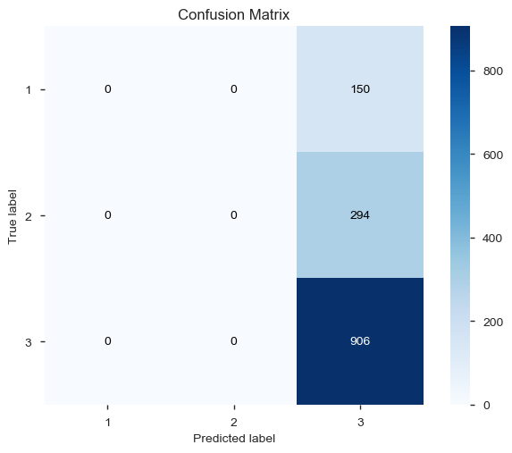

```python
y_preds_2 = svm_model_2.predict(X_test)
skplt.metrics.plot_confusion_matrix(y_test, y_preds_2)
plt.show()
```

```python
print(metrics.classification_report(y_test, y_preds_2, labels=[1,2,3], target_names=['Fatal', 'Serious', 'Slight']))
```

```
              precision    recall  f1-score   support

       Fatal       0.00      0.00      0.00       150
     Serious       0.00      0.00      0.00       294
      Slight       0.67      1.00      0.80       906

   micro avg       0.67      0.67      0.67      1350
   macro avg       0.22      0.33      0.27      1350
weighted avg       0.45      0.67      0.54      1350
```

**6) Entrenamiento del modelo - SVM con costo**

A continuación, estableceremos al algoritmo los pesos de las clases:

```python
svm_model_3 = svm.SVC(gamma='scale', decision_function_shape='ovo', class_weight='balanced')
svm_model_3.fit(X_train, y_train.values.ravel())
print('Accuracy of SVM classifier on training set: {:.2f}'.format(svm_model_3.score(X_train, y_train)))
print('Accuracy of SVM classifier on test set: {:.2f}'.format(svm_model_3.score(X_test, y_test)))
```

```
Accuracy of SVM classifier on training set: 0.44
Accuracy of SVM classifier on test set: 0.43
```

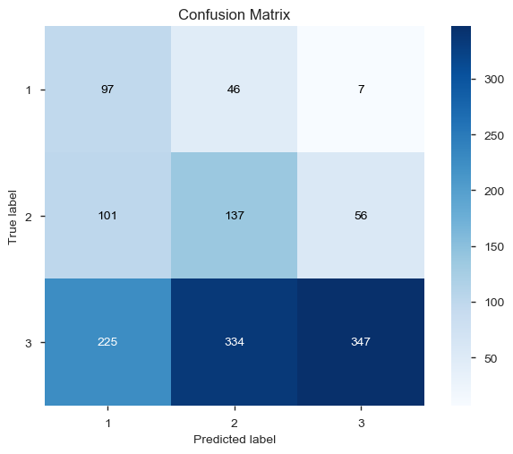

```python
y_preds_3 = svm_model_3.predict(X_test)
skplt.metrics.plot_confusion_matrix(y_test, y_preds_3)
plt.show()
```

```python
print(metrics.classification_report(y_test, y_preds_3, labels=[1,2,3], target_names=['Fatal', 'Serious', 'Slight']))
```

```
              precision    recall  f1-score   support

       Fatal       0.23      0.65      0.34       150
     Serious       0.26      0.47      0.34       294
      Slight       0.85      0.38      0.53       906

   micro avg       0.43      0.43      0.43      1350
   macro avg       0.45      0.50      0.40      1350
weighted avg       0.65      0.43      0.47      1350
```

Intentamos hallar los mejores hiper parámetros:

```python
# Establecemos los valores para la validación cruzada
grid_search_parameters_2 = [
    {'C': [0.01, 0.1, 1, 10, 100],
     'gamma': ['auto', 'scale'],
     'kernel': ['linear', 'poly', 'rbf', 'sigmoid'],
     'coef0': [0.1, 0.0, 1.0],
     'tol': [1e-4, 1e-3, 1e-2],
     'decision_function_shape': ['ovo'],
     'max_iter': [500, 1000, 2000],
     'class_weight': ['balanced']
    }
]
```

```python
grid_search_2 = GridSearchCV(svm.SVC(), grid_search_parameters_2, cv=20, n_jobs = -1, scoring='precision_weighted')
grid_search_2.fit(X_train, y_train.values.ravel())
```

```
GridSearchCV(cv=20, error_score='raise-deprecating',
       estimator=SVC(C=1.0, cache_size=200, class_weight=None, coef0=0.0,
  decision_function_shape='ovr', degree=3, gamma='auto_deprecated',
  kernel='rbf', max_iter=-1, probability=False, random_state=None,
  shrinking=True, tol=0.001, verbose=False),
       fit_params=None, iid='warn', n_jobs=-1,
       param_grid=[{'C': [0.01, 0.1, 1, 10, 100], 'gamma': ['auto', 'scale'], 'kernel': ['linear', 'poly', 'rbf', 'sigmoid'], 'coef0': [0.1, 0.0, 1.0], 'tol': [0.0001, 0.001, 0.01], 'decision_function_shape': ['ovo'], 'max_iter': [500, 1000, 2000], 'class_weight': ['balanced']}],
       pre_dispatch='2*n_jobs', refit=True, return_train_score='warn',
       scoring='precision_weighted', verbose=0)
```

```python
print(grid_search_2.best_params_)
```

```
{'C': 1, 'class_weight': 'balanced', 'coef0': 0.1, 'decision_function_shape': 'ovo', 'gamma': 'scale', 'kernel': 'rbf', 'max_iter': 2000, 'tol': 0.0001}
```

Realizamos el entrenamiento con los mejores hiper parametros hallados:

```python
# Poner hiper parametros aqui
svm_model_4 = svm.SVC(C=1, class_weight='balanced', coef0=0.1, decision_function_shape='ovo', gamma='scale', kernel='rbf', max_iter=2000, tol=0.0001)
svm_model_4.fit(X_train, y_train.values.ravel())
print('Accuracy of SVM classifier on training set: {:.2f}'.format(svm_model_4.score(X_train, y_train)))
print('Accuracy of SVM classifier on test set: {:.2f}'.format(svm_model_4.score(X_test, y_test)))
```

```
Accuracy of SVM classifier on training set: 0.53
Accuracy of SVM classifier on test set: 0.52
```

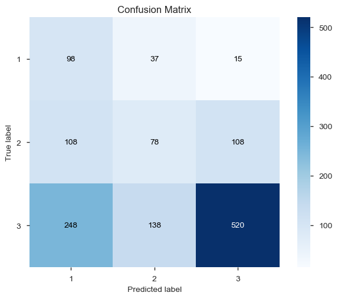

```python
y_preds_4 = svm_model_4.predict(X_test)
skplt.metrics.plot_confusion_matrix(y_test, y_preds_4)
plt.show()
```

```python
print(metrics.classification_report(y_test, y_preds_4, labels=[1,2,3], target_names=['Fatal', 'Serious', 'Slight']))
```

```
              precision    recall  f1-score   support

       Fatal       0.22      0.65      0.32       150
     Serious       0.31      0.27      0.29       294
      Slight       0.81      0.57      0.67       906

   micro avg       0.52      0.52      0.52      1350
   macro avg       0.44      0.50      0.43      1350
weighted avg       0.63      0.52      0.55      1350
```

```python
#print('w = ', svm_model_4.coef_)
print('b = ', svm_model_4.intercept_)
print('Indices of support vectors = ', svm_model_4.support_)
print('Support vectors = ', svm_model_4.support_vectors_)
print('Number of support vectors for each class = ', svm_model_4.n_support_)
print('Coefficients of the support vector in the decision function = ', np.abs(svm_model_4.dual_coef_))
```

```
b =  [-1.54773066 -0.79631346  0.74843503]
Indices of support vectors =  [  14   16   35 ... 3140 3141 3145]
Support vectors =  [[0.14285714 0.         1.         ... 0.125      0.5        0.        ]
 [0.         0.125      0.33333333 ... 0.125      0.         0.        ]
 [0.14285714 0.         1.         ... 0.5        0.         0.        ]
 ...
 [0.14285714 0.0625     0.5        ... 0.125      0.5        0.        ]
 [0.14285714 0.0625     1.         ... 0.125      0.         0.5       ]
 [0.28571429 0.         0.5        ... 0.125      0.         0.        ]]
Number of support vectors for each class =  [ 296  699 1780]
Coefficients of the support vector in the decision function =  [[3.         3.         3.         ... 0.50143266 0.         0.50143266]
 [3.         3.         3.         ... 0.50143266 0.50143266 0.50143266]]
```

**Conclusiones**

El balance de las clases claramente afecta el rendimiento del desempeño del algoritmo. En este caso, ajustar el parámetro por defecto que tenga en cuenta el desbalance de las clases fue fundamental para mejorar el aprendizaje de las clases.

Para el ejercicio es fundamental:

- Utilizar una métrica correcta de evaluación del modelo, ya que en el contexto multiclase no es posible utilizar las métricas binarias. Por tal motivo, luego de varias pruebas se usó precision_weighted
- Si bien, el algoritmo no tiene una precisión buena, con los parámetros se obtuvo un recall del 65% para la clase "Fatal" (La más importante y la menor del dataset), lo cual, se considera satisfactorio.
- La clase "Seria" no pudo distiguirse claramente de la "Fatal" y la "Leve". Ya que al aumentar la precisión sobre la clase minoritaria, dificulta más la distinción de esta.
- Es importante que las pruebas incluyan el parámetro max_iter ya que con frecuencia el algoritmo no converge elevando innecesariamente el tiempo de procesamiento